# checkpoint-01

18 de maio de 2017

## 1. Introdução

Neste trabalho iremos analisar os dados de commits no Github. Para tal, recolhemos uma amostra de dados da atividade global do Github. Os dados brutos contém a contagem de quantas pessoas editaram arquivos com cada extensão em cada dia de 2016 e 2017.

Nosso principal objetivo é responder as seguintes perguntas:

- **1) Para cada linguagem de programação, existe uma diferença significativa na sua popularidade durante a semana e durante o fim de semana?**
- **2) Existe uma diferença significativa na variação da popularidade das duas linguagens de programação quando você compara o quanto a popularidade de cada uma varia durante os dias da semana?**

### 1.1 Tratamento dos dados

É importante para esta análise ter conhecimento a respeito da data do commit e o dia da semana que corresponde à referida data. Portanto, utilizamos a biblioteca **lubridate** para obter estes dados, e armazenamos estas informações em novas colunas chamadas *data* e *dia_semana*.

```r
dados_github = dados_github %>%
  mutate(data = lubridate::ymd(paste(the_year, the_month, month_day)),
         dia_semana = lubridate::wday(data))
```

### 1.2 Descrição das variáveis

#### 1.2.1 file_extension

Extensão do arquivo o qual foi realizado o commit.

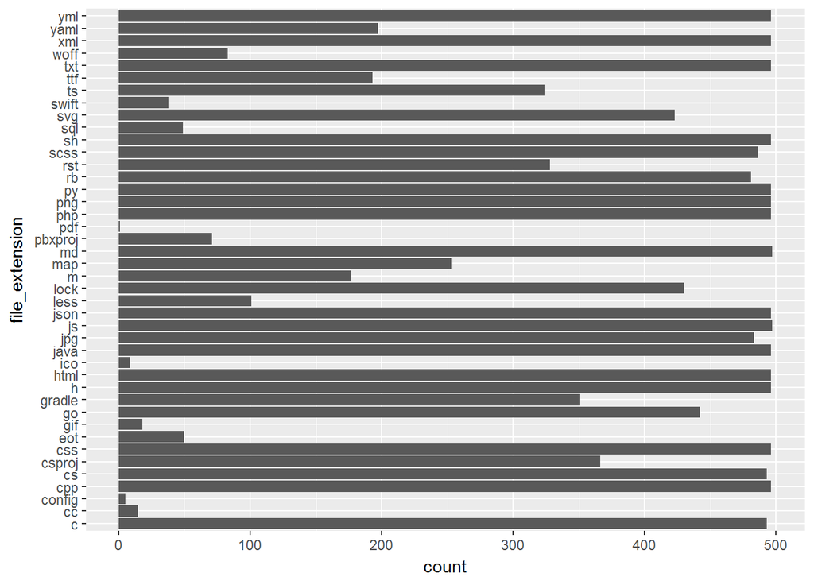

```r
dados_github %>%
  ggplot(aes(x = file_extension)) +
  geom_bar() +
  coord_flip()
```

#### 1.2.2 month_day

Dia (numérico) do mês o qual foi realizado o commit.

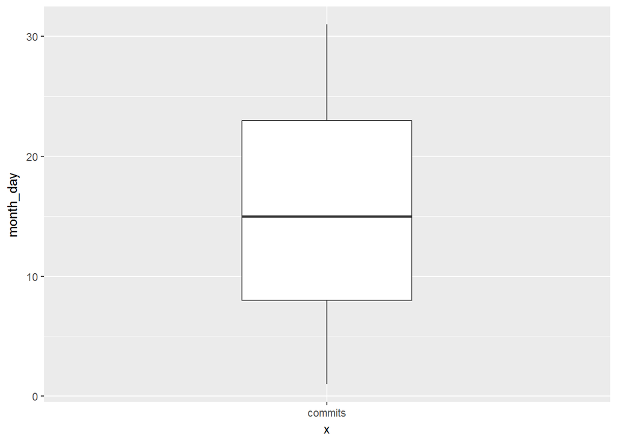

```r
dados_github %>%
    ggplot(aes(y = month_day, x = "commits")) +
    geom_boxplot(width = .3)
```

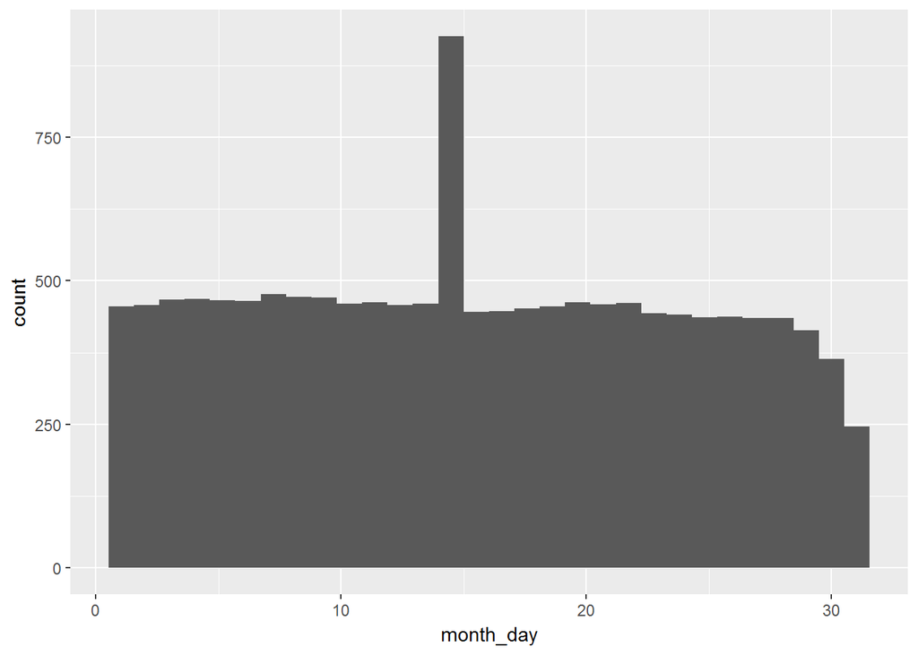

```r
dados_github %>%
    ggplot(aes(x = month_day)) +
    geom_histogram(bins = 30)
```

### 1.2.3 the_month

Mês (numérico) em que o commit foi realizado.

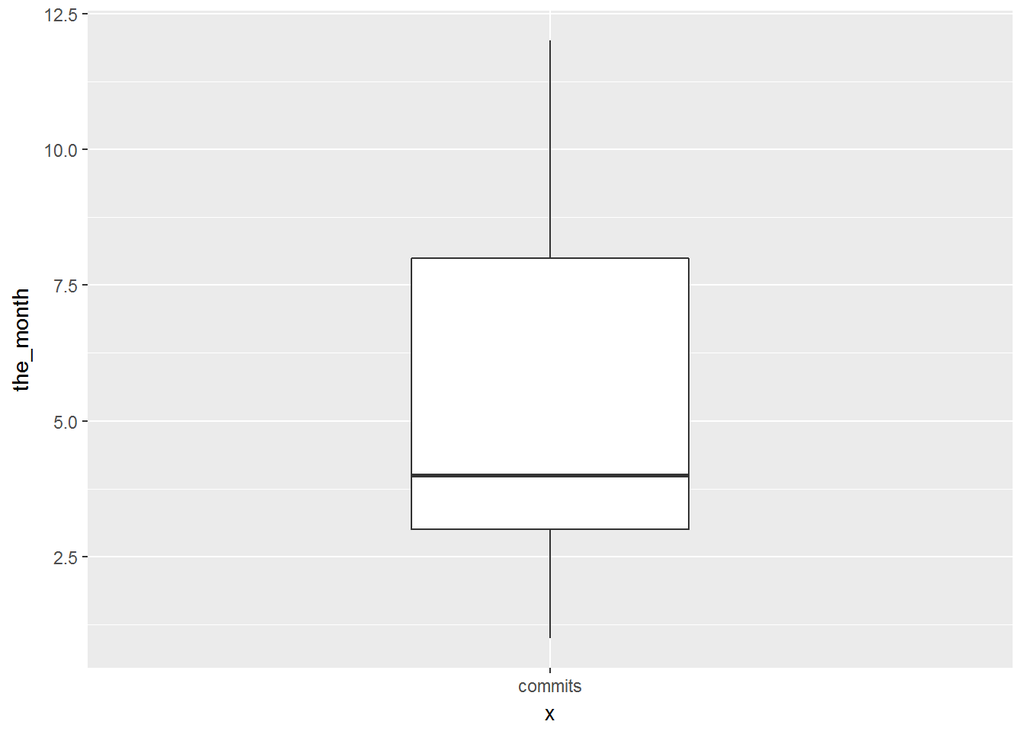

```r
dados_github %>%
    ggplot(aes(y = the_month, x = "commits")) +
    geom_boxplot(width = .3)
```

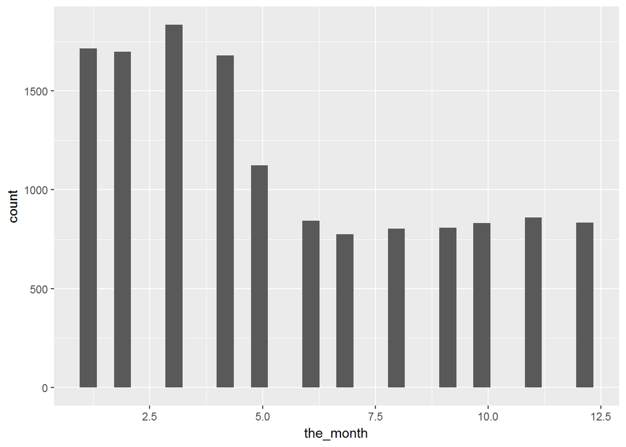

```r
dados_github %>%
    ggplot(aes(x = the_month)) +
    geom_histogram(bins = 30)
```

### 1.2.4 the_year

Ano (numérico) em que o commit foi realizado.

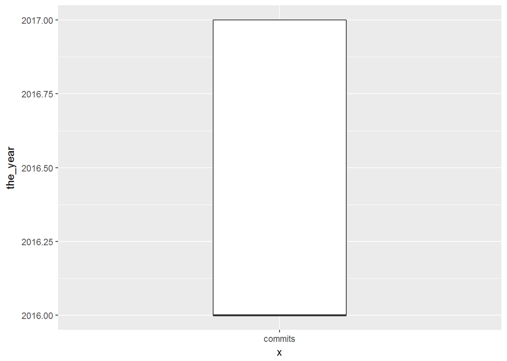

```r
dados_github %>%
    ggplot(aes(y = the_year, x = "commits")) +
    geom_boxplot(width = .3)
```

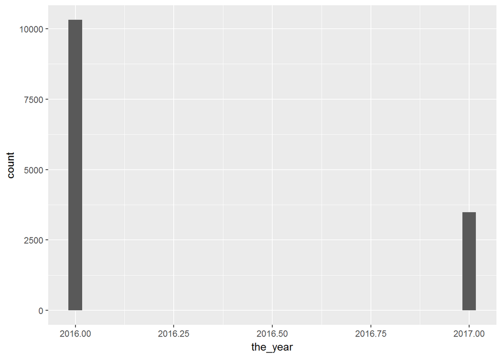

```r
dados_github %>%
    ggplot(aes(x = the_year)) +
    geom_histogram(bins = 30)
```

### 1.2.5 users

Número de usuário que realizaram commit numa determinada data para uma linguagem de programação. Também conhecido nessa análise como métrica para popularidade.

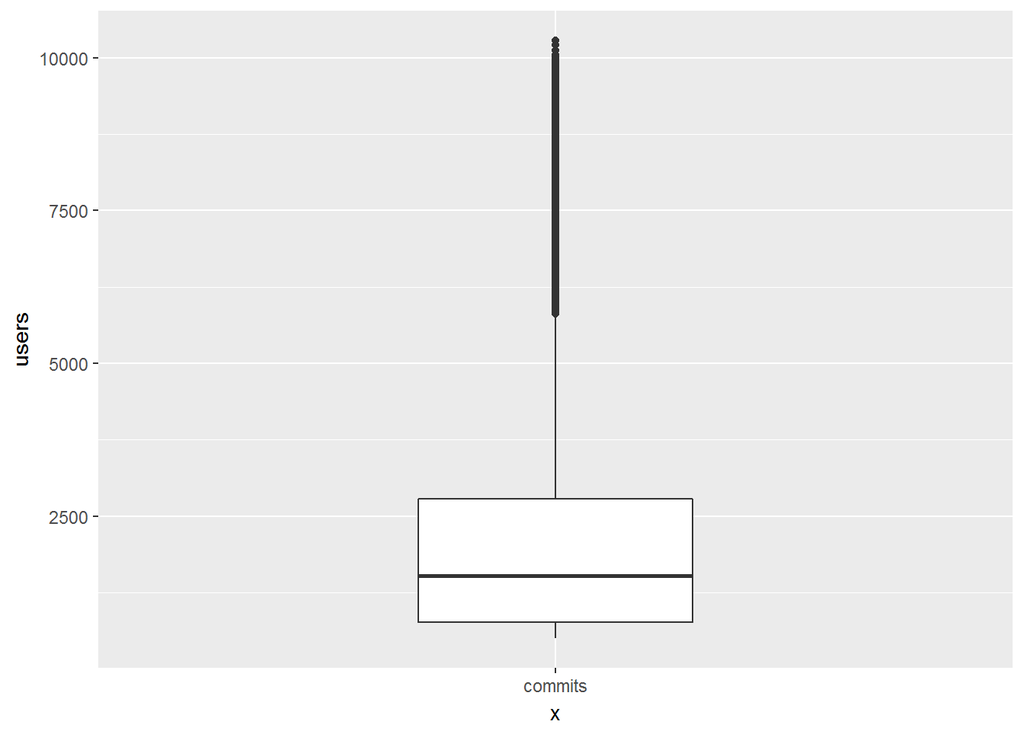

```r
dados_github %>%
    ggplot(aes(y = users, x = "commits")) +
    geom_boxplot(width = .3)
```

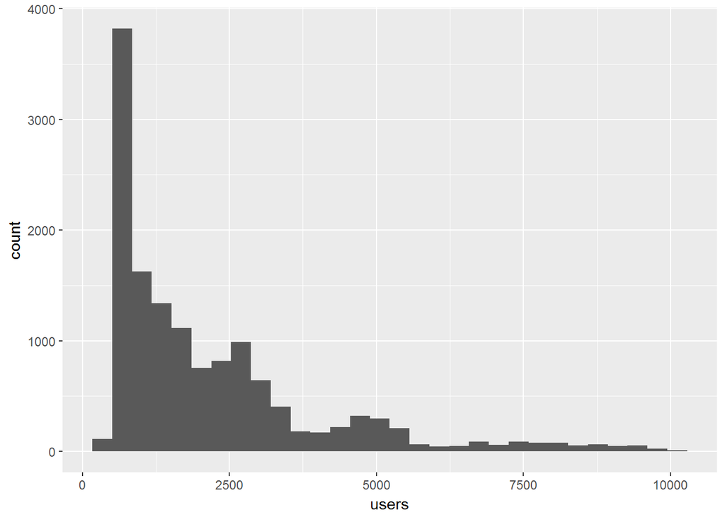

```r
dados_github %>%
    ggplot(aes(x = users)) +
    geom_histogram(bins = 30)
```

## 2. Respondendo as questões

#### 1) Para cada linguagem de programação, existe uma diferença significativa na sua popularidade durante a semana e durante o fim de semana?

Inicialmente, realizamos algumas manipulações nos dados para que nossa análise se torne mais objetiva e de fácil entendimento. Portanto, separamos os dados em 4(quatro) grupos:

- commits em Java no fim de semana (github_java_fds)
- commits em Java durante a semana (github_java_sem)
- commits em Python no fim de semana (github_python_fds)
- commits em Python durante a semana (github_python_sem)

Além disso, criamos uma nova coluna (isFDS) de valor booleando (True ou False), onde o valor será verdadeiro se o dia do commit é no fim de semana, ou será falso caso contrário.

```r
# Linguagem: Java (java)

github_java = dados_github %>%
  filter(file_extension == "java") %>%
  mutate(isFDS = dia_semana > 5)

github_java_fds = github_java %>%
  filter(dia_semana > 5)

github_java_sem = github_java %>%
  filter(dia_semana < 6)
```

```r
# Linguagem: Python (py)

github_python = dados_github %>%
  filter(file_extension == "py") %>%
  mutate(isFDS = dia_semana > 5)

github_python_fds = github_python %>%
  filter(dia_semana > 5)

github_python_sem = github_python %>%
  filter(dia_semana < 6)
```

Nesse ponto, é necessário calcular os intervalos de confiança da média da popularidade para as linguagens de programação Java e Python. Dessa forma, será possível comparar a média da popularidade para os 4(quatro) grupos os quais estamos interessados em analisar. Além disso, plotaremos um gráfico que representa estes intervalos de confiança.

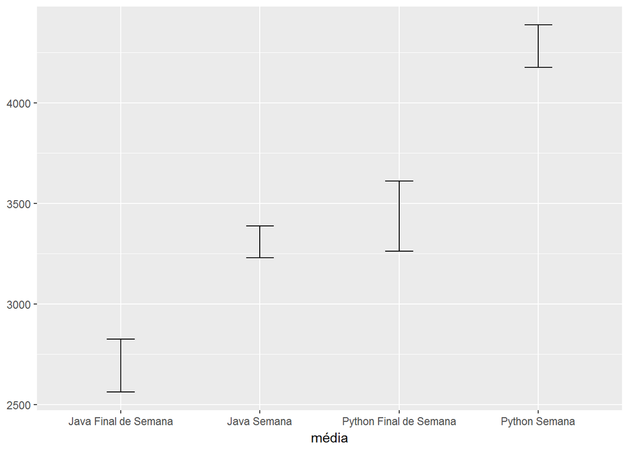

```r
# IC para Java no final de semana
java_mean.fds =  bootstrap(github_java_fds, mean(users)) %>%
  CI.bca(probs = c(.025, .975))

# IC para Java durante a semana
java_mean.sem = bootstrap(github_java_sem, mean(users)) %>%
  CI.bca(probs = c(.025, .975))

# IC para Python no final de semana
python_mean.fds = bootstrap(github_python_fds, mean(users)) %>%
  CI.bca(probs = c(.025, .975))

# IC para Python durante a semana
python_mean.sem = bootstrap(github_python_sem, mean(users)) %>%
  CI.bca(probs = c(.025, .975))

df = data.frame(rbind(java_mean.fds,
                      java_mean.sem,
                      python_mean.fds,
                      python_mean.sem))

df$`média` = c("Java Final de Semana", "Java Semana", "Python Final de Semana", "Python Semana")

df %>%
  ggplot(aes(x = `média`, ymin = X2.5., ymax = X97.5.)) +
  geom_errorbar(width = .2)
```

Dado o gráfico acima, podemos observar que aparentemente existem diferenças significativas de popularidade durante a semana e no fim de semana para as duas linguagens de programação. No entanto, este gráfico não pode nos dar a certeza dessa afirmação, é necessário quantificar essa diferença para saber se é realmente significativa.

Utilizando a biblioteca bootstrap2, podemos calcular a diferença dos intervalos de confiança para as médias de popularidade. Dessa forma, é possível concluir se a diferença é significativa. O gráfico a seguir calcula a diferenças dos intervalos de confiança para a linguagem de programação Java.

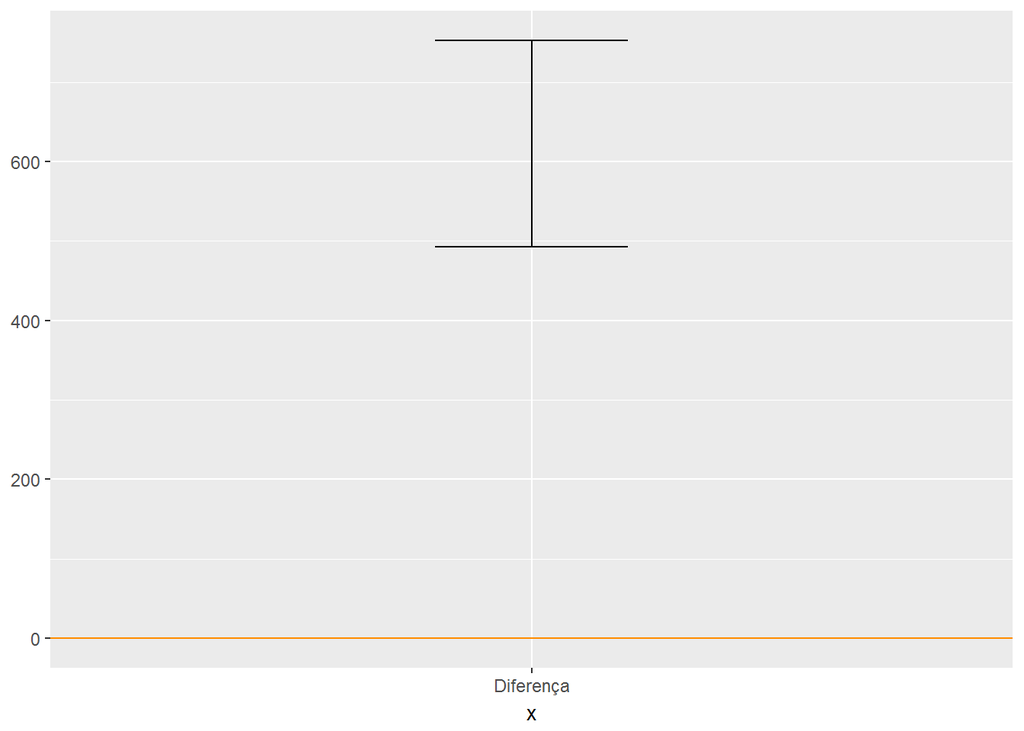

```r
# Java
b.diff.means = bootstrap2(github_java$users,
                          treatment = github_java$isFDS,
                          mean)

means.diff = CI.percentile(b.diff.means, probs = c(.05, .95))

data.frame(means.diff) %>%
  ggplot(aes(x = "Diferença", ymin = X5., ymax = X95.)) +
  geom_errorbar(width = .2) +
  geom_hline(yintercept = 0, colour = "darkorange")
```

De acordo com o gráfico acima, existe sim diferença significativa na popularidade durante a semana e o fim de semana para linguagem Java, tal que o valor 0(zero) não pertence ao intervalo de confiança da diferença. Portanto, podemos concluir que a média de commits da linguagem Java é maior durante a semana do que no fim de semana. Precisamos agora plotar o mesmo gráfico para a linguagem de programação Python.

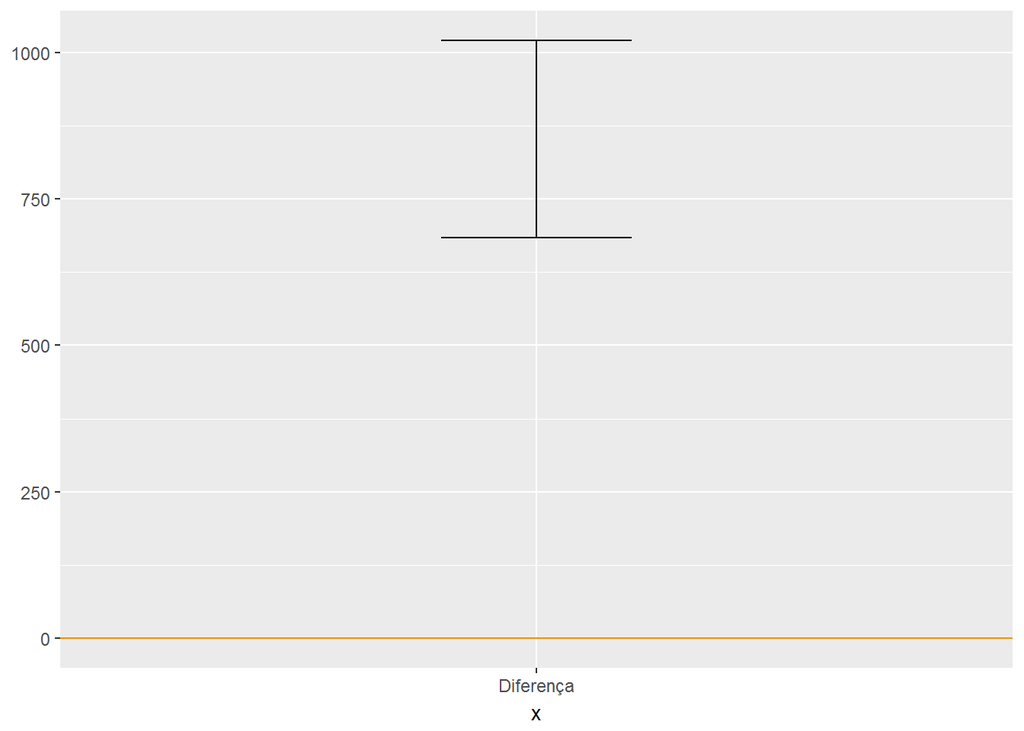

```r
# Python
b.diff.means = bootstrap2(github_python$users,
                          treatment = github_python$isFDS,
                          mean)

means.diff = CI.percentile(b.diff.means, probs = c(.05, .95))

data.frame(means.diff) %>%
  ggplot(aes(x = "Diferença", ymin = X5., ymax = X95.)) +
  geom_errorbar(width = .2) +
  geom_hline(yintercept = 0, colour = "darkorange")
```

De acordo com o gráfico acima, existe sim diferença significativa na popularidade durante a semana e o fim de semana para a linguagem de programação Python, tal que o valor 0(zero) não pertence ao intervalo de confiança da diferença. Portanto, podemos concluir que a média de commits da linguagem Python é maior durante a semana do que no fim de semana.

Respondendo à pergunta (1): Sim, existe diferença significativa na popularidade entre commits durante a semana e no fim de semana para as duas linguagens de programação selecionadas.

#### 2) Existe uma diferença significativa na variação da popularidade das duas linguagens de programação quando você compara o quanto a popularidade de cada uma varia durante os dias da semana?

Para esta questão, precisamos selecionar todos os commit feitos nas linguagens Java e Python durante a semana. Atribuímos estes dados a variável (github_py_java).

```r
github_py_java = dados_github %>%
  filter(file_extension == "java"
         | file_extension == "py",
         dia_semana < 6)
```

Dessa vez, estamos interessados em analisar a variação da popularidade, então podemos calcular intervalos de confiança utilizando o desvio padrão da popularidade nas linguagens de programação Java e Python, apenas para os commits realizados durante a semana. Plotaremos um gráfico que representa adequadamente estes intervalos de variação.

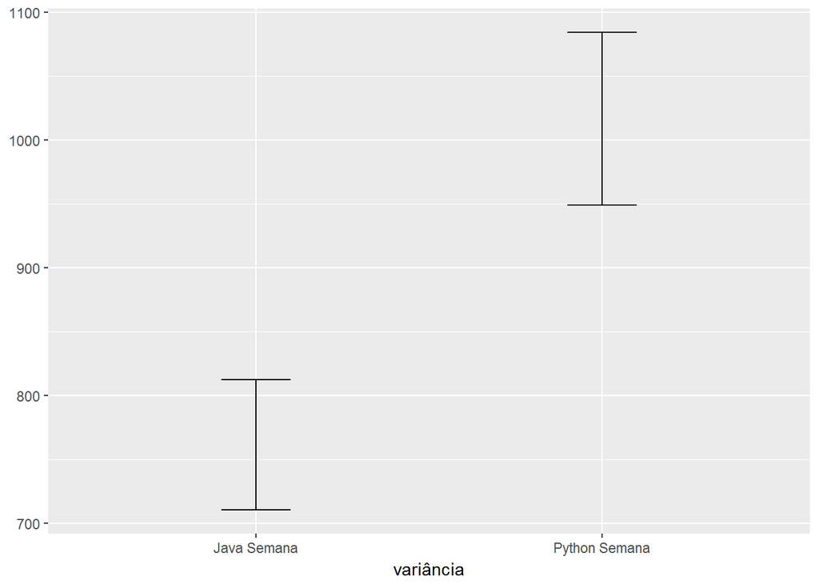

```r
# IC para Java durante a semana
java_sd.sem = bootstrap(github_java_sem, sd(users)) %>%
  CI.bca(probs = c(.025, .975))

# IC para Python durante a semana
python_sd.sem = bootstrap(github_python_sem, sd(users)) %>%
  CI.bca(probs = c(.025, .975))

df = data.frame(rbind(java_sd.sem,
                      python_sd.sem))

df$`variância` = c("Java Semana", "Python Semana")

df %>%
  ggplot(aes(x = `variância`, ymin = X2.5., ymax = X97.5.)) +
  geom_errorbar(width = .2)
```

Aparentemente, existe uma diferença significativa na variação da popularidade entre Java e Python durante a semana. No entanto, este gráfico não pode nos dar a certeza dessa afirmação, é necessário quantificar essa diferença para saber se é realmente significativa.

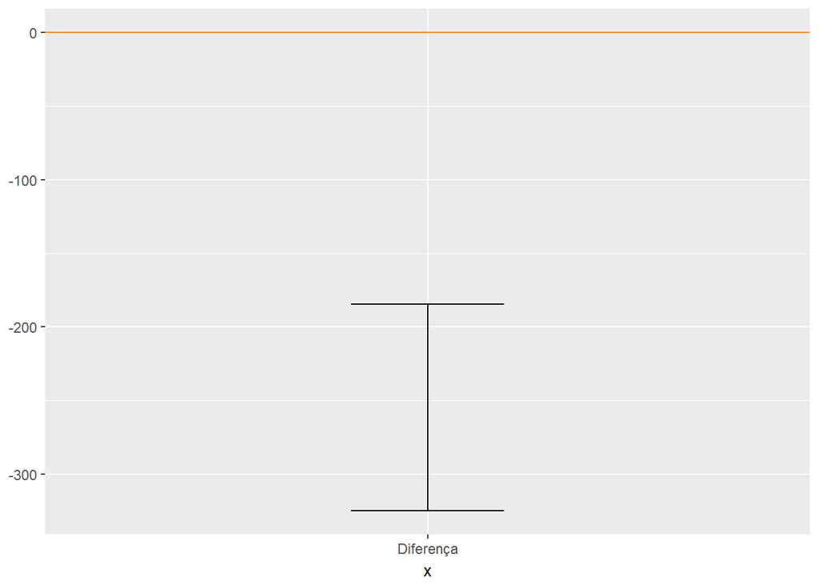

```r
# Diferença das variações
b.diff.dp = bootstrap2(github_py_java$users,
                          treatment = github_py_java$file_extension,
                          sd)

dp.diff = CI.percentile(b.diff.dp, probs = c(.05, .95))

data.frame(dp.diff) %>%
  ggplot(aes(x = "Diferença", ymin = X5., ymax = X95.)) +
  geom_errorbar(width = .2) +
  geom_hline(yintercept = 0, colour = "darkorange")
```

De acordo com o gráfico acima, existe sim diferença significativa na variação da popularidade durante a semana entre as linguagens de programação Java e Python, tal que o valor 0(zero) não pertence ao intervalo de confiança da diferença. Portanto, podemos concluir que a variação do número commits da linguagem Python é maior do que os commits para a linguagem Java durante a semana.

Respondendo à pergunta (2): Sim, existe diferença significativa na variação da popularidade das linguagens de programação Java e Python para os commits realizados durante a semana.